# R, statistics and reproducible research in the omics era

Dr. Rima Chaudhuri

08 December, 2015

## Learning Objectives

> - Data exploration of two transcriptomics datasets (human and mouse).
> - Differential expression analysis for omics data using LIMMA.
> - Writing your own functions for data analysis.
> - Reproducible research - generating a report inclusive of code.

## 0.1 Executive summary

We aim to identify differentially expressed (DE) genes in two separate microarray datasets from two different species with similar experimental design and compare the results. We will look into mouse muscle gene expression (GE) data post high fat feeding (HFF) and compare it to GE of mouse fed a normal chow diet. In parallel, we will practice using the same analysis steps on human muscle gene expression data of insulin resistant and insulin sensitive individuals. We will try to find the overlap between genes altered in mice under HFF and dysregulated genes in insulin resistant humans.

## 0.2 Libraries to load

```r
library(knitr)
library(limma)
library(reshape2)
library(ggplot2)
library(devtools)
install_github("vqv/ggbiplot")
library(ggbiplot)
library(gplots)
```

## 0.3 Introduction to datasets

> - Human skeletal muscle: Insulin resistant (IR) and sensitive (IS) subjects (ArrayExpresss GSE13070, baseline data)
> - Mouse skeletal muscle under HFF: Normal fed (Mchow) vs. after 5 (Mhi5) and 42 days (Mhi42) of HFF (ArrayExpress GSE73036)

```r
#read in pre-processed datasets
#Pre-processing of raw files done using affyPLM (link)

#HUMAN GE data
human = read.csv("Human.GSE13070.baseline.csv", header=T, row.names=1)

#MOUSE (GE data)
mouse = read.csv("Mouse.HFD.muscle.csv", header=T, row.names=1)
```

# 1 Omics data exploration

You can extract basic information about the data set using these functions, such as how many genes and samples your data set has. Along the way, you will also learn how to write a function

```r
#mouse data
tellMeMore <- function(dat){
no.of.genes = nrow(dat) # number of rows in GEdata
no.of.samples = ncol(dat) # number of cols in GEdata
dimension = dim(dat) # dimension of GEdata
samplenames = colnames(dat) # names of columns
first.few.rownames = rownames(dat)[1:5]
return(list(no.of.genes = no.of.genes, no.of.samples = no.of.samples, data.size = dimension, sample.names=samplenames, first.few.gene.symbols=first.few.rownames))
}

#Call function to find basic information about this dataset
tellMeMore(mouse)
```

```
## $no.of.genes
## [1] 20743
##
## $no.of.samples
## [1] 12
##
## $data.size
## [1] 20743    12
##
## $sample.names
##  [1] "Mchow.1" "Mchow.2" "Mchow.3" "Mchow.4" "Mhi5.1"  "Mhi5.2"  "Mhi5.3"
##  [8] "Mhi5.4"  "Mhi42.1" "Mhi42.2" "Mhi42.3" "Mhi42.4"
##
## $first.few.gene.symbols
## [1] "0610005C13RIK" "0610006L08RIK" "0610007P14RIK" "0610009B22RIK"
## [5] "0610009L18RIK"
```

```r
#how many chow samples are in this data?
n = length(grep("chow", colnames(mouse)))
n
```

```
## [1] 4
```

```r
#Can you find out how many samples we have for 5d and 42d HFF?

# To see a snapshot of this data
View(mouse)
#or
head(mouse)
```

```
##               Mchow.1 Mchow.2 Mchow.3 Mchow.4 Mhi5.1 Mhi5.2 Mhi5.3  Mhi5.4
## 0610005C13RIK   6.518   6.283  6.3020   6.489  6.352  6.142  6.203  5.9820
## 0610006L08RIK   6.538   6.816  6.6140   6.716  6.675  6.386  6.783  6.6760
## 0610007P14RIK   8.219   8.253  8.1830   8.396  8.056  8.088  8.244  8.1610
## 0610009B22RIK  11.154  11.042 11.1620  11.057 11.184 11.339 11.248 11.2040
## 0610009L18RIK  10.413  10.219 10.5800  10.072 10.334 10.480 10.417 10.3940
## 0610009O20RIK   9.452   9.329  9.4495   9.340  9.279  9.303  9.334  9.2745
##               Mhi42.1 Mhi42.2 Mhi42.3 Mhi42.4
## 0610005C13RIK   6.471   6.179   6.428  6.4940
## 0610006L08RIK   6.627   6.827   6.724  6.5460
## 0610007P14RIK   8.241   8.284   8.229  8.3030
## 0610009B22RIK  11.175  11.194  11.257 11.3000
## 0610009L18RIK  10.004  10.106  10.120 10.0970
## 0610009O20RIK   9.324   9.193   9.287  9.3095
```

### 1.0.1 Can you find some details about the human data now?

### 1.0.2 Questions to consider

1. How many genes are in the human transriptomics data?
2. How many muscle samples are we looking at?
3. Are the insulin resistant and insulin sensitive groups balanced in sample size?

# 2 Basic quality control steps for big data sets

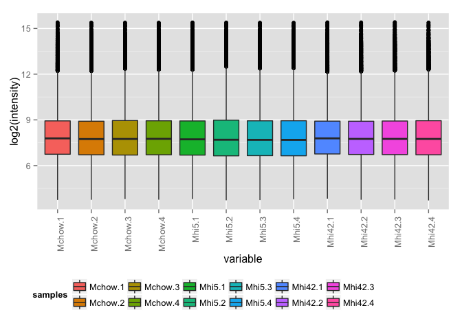

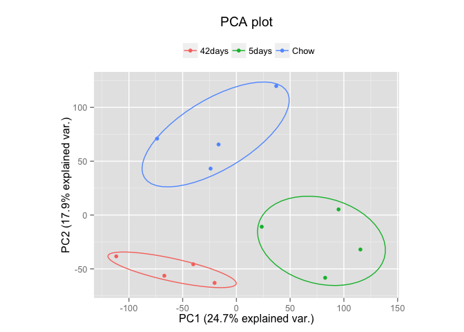

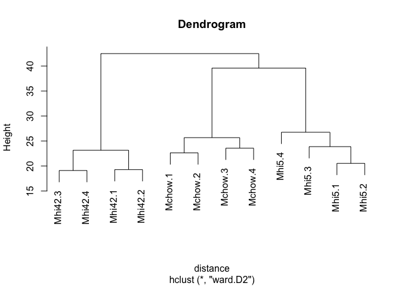

```r
QC <- function(dat, data.groups){
#boxplot
dfm <- melt(dat)
p = ggplot(data=dfm) + geom_boxplot(aes(x=variable,y=value, fill=as.factor(variable))) + theme(axis.text.x = element_text(angle = 90, hjust = 1)) + ylab("log2(intensity)") + theme(legend.position="bottom",legend.direction="horizontal") + guides(fill=guide_legend(ncol=10, title="samples"))
print(p)

#Principal Component Analysis
pca <- prcomp(t(na.omit(dat)) ,center = TRUE, scale. = TRUE)
g <- ggbiplot(pca, obs.scale = 1, var.scale = 1, pc.biplot = TRUE, groups = data.groups, ellipse = TRUE,
              labels=NULL, circle = TRUE, var.axes=FALSE )
g <- g + scale_color_discrete(name = '')
g <- g + theme(legend.direction = 'horizontal',legend.position = 'top') + ggtitle("PCA plot")
print(g)

#dendrogram
distance = dist(t(dat), method="euclidean")
HCtree = hclust(distance, method="ward.D2")
plot(HCtree, main = "Dendrogram")
}

data.groups.mouse = c(rep("Chow",4), rep("5days",4) , rep("42days", 4))
QC(mouse, data.groups.mouse)
```

## 2.1 Practice with human data

### 2.1.1 Questions to consider

1. Does the data look normalized?
2. Do the IR and IS groups clusters like they should?
3. If samples in a group don’t cluster like they should, is that a problem for further statistical analysis? Why?

# 3 Selecting our favourite genes and visualizing its expression across groups

```r
selectgenes = function(genename, data)
  {
    return(grep(genename, rownames(data)))
  }

selectgenes("CTNNB1", mouse)
```

```
## [1] 6382
```

```r
selectgenes("FTO", mouse)
```

```
## [1] 8732
```

```r
#Distribution of Fto gene expression across the 3 groups in mouse GE
FTO.gene = t(mouse[selectgenes("FTO", mouse),])
summary(FTO.gene)
```

```
##       FTO
##  Min.   : 9.648
##  1st Qu.: 9.781
##  Median : 9.806
##  Mean   : 9.838
##  3rd Qu.: 9.899
##  Max.   :10.040
```

```r
CTNNB1.gene = t(mouse[selectgenes("CTNNB1", mouse),])
summary(CTNNB1.gene)
```

```
##      CTNNB1
##  Min.   :10.37
##  1st Qu.:10.65
##  Median :10.87
##  Mean   :10.81
##  3rd Qu.:10.98
##  Max.   :11.11
```

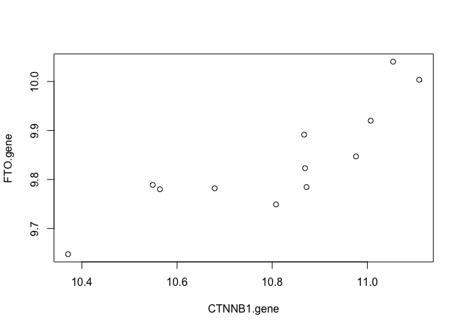

```r
#Are the gene expression of these 2 genes correlated?
plot(CTNNB1.gene, FTO.gene)
```

```r
cor(CTNNB1.gene, FTO.gene)
```

```
##              FTO
## CTNNB1 0.8485617
```

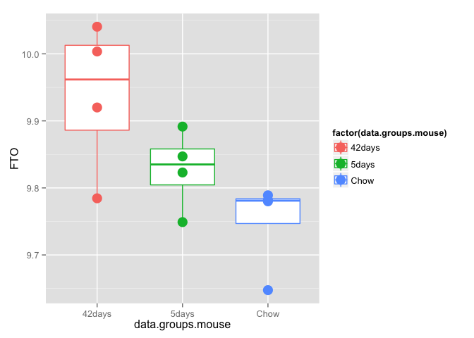

```r
#Visualize GE of chosen genes across groups
FTO.gene.df = data.frame(FTO.gene, data.groups.mouse)
ggplot(FTO.gene.df, aes(x = data.groups.mouse, y = FTO, color=factor(data.groups.mouse))) + geom_boxplot() + geom_point(size=5)
```

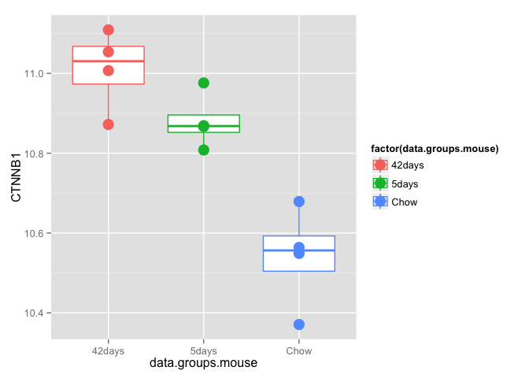

```r
CTNNB1.gene.df = data.frame(CTNNB1.gene, data.groups.mouse)
ggplot(CTNNB1.gene.df, aes(x = data.groups.mouse, y = CTNNB1, color=factor(data.groups.mouse))) + geom_boxplot() + geom_point(size=5)
```

## 3.1 Practice with human data

Hints: Create a human data group first, IR : 42 samples and IS : 17 samples ### Questions to consider 1. What does the expression of Fto and Ctnnb1 look like in the human data? 2. Do you see any marked difference between their expression in mouse vs. human data? 3. Are the GE pattern for CTNNB1 and FTO more or less correlated in human data?

# 4 Statistical Analysis

### 4.0.1 Welch t-tests (5d vs chow) and (42d vs chow) for selected gene

```r
TwoSampleTT <- function(gene, grps, control, treat){
cntl = gene[grps == control,1]
trt = gene[grps == treat, 1]
print(t.test(trt, cntl))
}

TwoSampleTT(CTNNB1.gene.df, data.groups.mouse, "Chow", "5days")
```

```
##
##  Welch Two Sample t-test
##
## data:  trt and cntl
## t = 4.6737, df = 4.6636, p-value = 0.006511
## alternative hypothesis: true difference in means is not equal to 0
## 95 percent confidence interval:
##  0.1485363 0.5299637
## sample estimates:
## mean of x mean of y
##  10.88000  10.54075
```

```r
TwoSampleTT(FTO.gene.df, data.groups.mouse, "Chow", "5days")
```

```
##
##  Welch Two Sample t-test
##
## data:  trt and cntl
## t = 1.7224, df = 5.8945, p-value = 0.1367
## alternative hypothesis: true difference in means is not equal to 0
## 95 percent confidence interval:
##  -0.03329219  0.18929219
## sample estimates:
## mean of x mean of y
##  9.827625  9.749625
```

> - What does the t-test tell you when comparing Chow and 42 days for these two genes?

### 4.0.2 Linear models

“A typical model has the form response ~ terms where response is the response/outcome (y) vector and terms (x) is a series of terms which specifies a linear predictor for response.”

The term “regression” originates from 19th century, where a statistician observed that children’s heights tended to “regress” towards the population mean in relation to their parent’s heights. We will use this simple example data to understand some concepts about regression models.

```r
galton <- read.csv("http://blog.yhathq.com/static/misc/galton.csv",
                    header=TRUE, stringsAsFactors=FALSE)
summary(galton)
```

```
##      child           parent
##  Min.   :61.70   Min.   :64.00
##  1st Qu.:66.20   1st Qu.:67.50
##  Median :68.20   Median :68.50
##  Mean   :68.09   Mean   :68.31
##  3rd Qu.:70.20   3rd Qu.:69.50
##  Max.   :73.70   Max.   :73.00
```

```r
# representing the relationship between parents' heights (X) and children's heights (y) OR in other words child's height is the response and we are trying to predict this using parent's height
fit <- lm(child ~ parent, data=galton)
summary(fit)
```

```
##
## Call:
## lm(formula = child ~ parent, data = galton)
##
## Residuals:
##     Min      1Q  Median      3Q     Max
## -7.8050 -1.3661  0.0487  1.6339  5.9264
##
## Coefficients:
##             Estimate Std. Error t value Pr(>|t|)
## (Intercept) 23.94153    2.81088   8.517   <2e-16 ***
## parent       0.64629    0.04114  15.711   <2e-16 ***
## ---
## Signif. codes:  0 '***' 0.001 '**' 0.01 '*' 0.05 '.' 0.1 ' ' 1
##
## Residual standard error: 2.239 on 926 degrees of freedom
## Multiple R-squared:  0.2105, Adjusted R-squared:  0.2096
## F-statistic: 246.8 on 1 and 926 DF,  p-value: < 2.2e-16
```

```r
coef(fit) # extract coefficients
```

```
## (Intercept)      parent
##  23.9415302   0.6462906
```

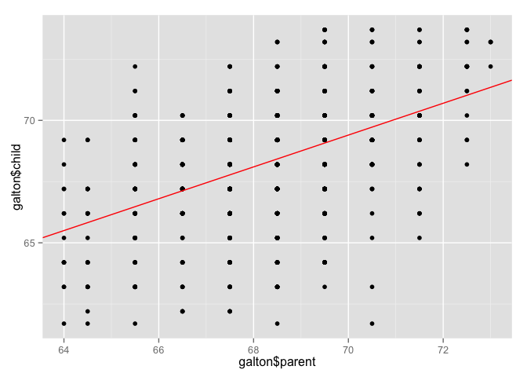

```r
qplot(galton$parent, galton$child) + geom_abline(intercept = 23.9, slop = 0.65, colour="red") # the intercept and slope values are obtained from fit
```

Now coming back to the gene expression data ### Differential expression analysis of the entire mouse data using moderated t-test from LIMMA package

```r
f = factor(c(rep(1,4), rep(2,4), rep(3,4)), labels = c("Chow", "day5","day42"))
design = model.matrix(~ 0 + f)
colnames(design) <- c("Chow", "day5","day42")
design
```

```
##    Chow day5 day42
## 1     1    0     0
## 2     1    0     0
## 3     1    0     0
## 4     1    0     0
## 5     0    1     0
## 6     0    1     0
## 7     0    1     0
## 8     0    1     0
## 9     0    0     1
## 10    0    0     1
## 11    0    0     1
## 12    0    0     1
## attr(,"assign")
## [1] 1 1 1
## attr(,"contrasts")
## attr(,"contrasts")$f
## [1] "contr.treatment"
```

```r
fit <- lmFit(mouse , design) # fitting data to a linear model
contrast.matrix <- makeContrasts(day5-Chow , day42-Chow, levels=design)  # defining group comparisons
fit2 <- contrasts.fit(fit, contrast.matrix) # convert the coefficients of the design matrix into these 2 contrasts which are to be tested equal to zero
fit2 <- eBayes(fit2) # With a series of related parameter estimates & standard errors, eBayes computes moderated t-statistics of differential expression by empirical Bayes shrinkage of the standard errors towards a common value.

DE.results.5ddHFF = topTable(fit2, coef=1, number=Inf)
DE.results.42dHFF = topTable(fit2, coef=2, number=Inf)
head(DE.results.5ddHFF)
```

```
##            logFC   AveExpr          t      P.Value    adj.P.Val        B
## CCDC122 -0.67250  7.606833 -10.578986 2.259166e-08 0.0004686189 8.765522
## MGST2   -0.57300  7.026333  -8.896195 2.188247e-07 0.0022695408 6.946538
## FASN    -2.15250 10.485250  -7.670030 1.396531e-06 0.0079321030 5.376662
## TMEM252  0.68350  8.549500   7.612827 1.529596e-06 0.0079321030 5.297868
## HSDL2    0.40275 10.639250   7.300344 2.533689e-06 0.0105112630 4.858316
## CD19    -0.35175  8.774167  -6.759521 6.257437e-06 0.0156618786 4.060441
```

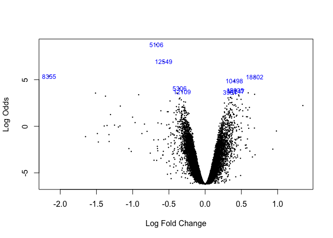

```r
# What is adj.P.Val? and why do we need this?

volcanoplot(fit = fit2, coef=1, highlight = 10) #visualize DE genes
```

```r
#let's save the top 30 DE genes post 5 days of high fat feeding
top30 = rownames(topTable(fit2, coef=1, number=30))
```

Please note that what we are doing here is supervised clustering, for visulization purpose only.

```r
top30 # tells you what these top 30 DE genes are
```

```
##  [1] "CCDC122"       "MGST2"         "FASN"          "TMEM252"
##  [5] "HSDL2"         "CD19"          "PPP2R2A"       "PCNA"
##  [9] "LZIC"          "AUTS2"         "SDCCAG8"       "4930563E18RIK"
## [13] "ELOVL6"        "1300002E11RIK" "DHX9"          "BTG2"
## [17] "CES1F"         "GLT28D2"       "OPA1"          "SLC25A1"
## [21] "PCSK9"         "CEP68"         "NDUFAF1"       "TUBB1"
## [25] "CLIP1"         "3222401L13RIK" "PAGR1A"        "LMOD2"
## [29] "SCGB3A2"       "GIMAP5"
```

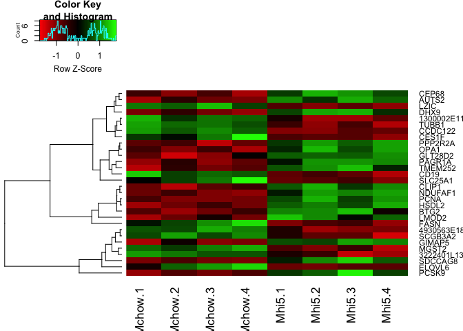

```r
subset = mouse[top30, data.groups.mouse %in% c("Chow", "5days")] # parse out their expression values for chow & 5d
heatmap.2(as.matrix(subset), col=redgreen(100), scale="row", trace="none", Colv = FALSE) # visualize it
```

```r
# Further filtering based on fold change and multiple hypothesis testing correction method
top.5d = topTable(fit2, coef=1, adjust.method = "fdr", lfc=0.5)
```

> - Can you visualize these (to.5d) as a heatmap now?
> - What happened to CTNNB1 and FTO when we performed moderated t-test? Are they still significant?

```r
DE.results.5ddHFF[selectgenes("CTNNB1", DE.results.5ddHFF),]
```

```
##          logFC  AveExpr        t      P.Value  adj.P.Val         B
## CTNNB1 0.33925 10.81042 4.918407 0.0001829724 0.02618666 0.9898518
```

```r
DE.results.42dHFF[selectgenes("CTNNB1", DE.results.42dHFF),]
```

```
##          logFC  AveExpr       t      P.Value   adj.P.Val        B
## CTNNB1 0.46975 10.81042 6.81038 5.737747e-06 0.001578813 4.259321
```

```r
DE.results.5ddHFF[selectgenes("FTO", DE.results.5ddHFF),]
```

```
##     logFC  AveExpr        t  P.Value adj.P.Val         B
## FTO 0.078 9.838125 1.275704 0.221369 0.4456397 -5.392302
```

```r
DE.results.42dHFF[selectgenes("FTO", DE.results.42dHFF),]
```

```
##      logFC  AveExpr        t     P.Value  adj.P.Val         B
## FTO 0.1875 9.838125 3.066596 0.007797494 0.08267653 -2.666597
```

## 4.1 Practice with human data

### 4.1.1 Questions to consider

1. What are the top 100 genes that are differentially expressed between IR and IS groups?
2. Do they overlap with the top 100 gene changes from the mouse data (at any time point)? Hint: use function ‘intersect’
3. Are the fold changes of the common genes correlated?
4. What are the Welch Two Sample t-test results like for CTNNB1 and FTO in the human data?
5. What happens to CTNNB1 and FTO in the human data post moderated t-test?
6. Can you conclude anything about the difference or similarity of results between human and mouse GE data?

## 4.2 Clustering using a set of predefined genes known to be associated with obesity

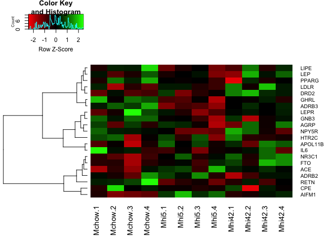

```r
#genes from GWAS studies known to be associated with obesity
ogenes = c("FLG2", "APOL1", "FTO", "AIFM1","GHRL", "AGRP", "CPE", "HTR2A", "NPY5R",
           "ACE", "ADRB2", "ADRB3", "DRD2", "GNB3", "HTR2C", "IL6", "INS", "LDLR", "LEP", "LEPR", "LIPE",
           "MC4R", "NR3C1", "PPARG", "RETN")

heatmap.2(na.omit(as.matrix(mouse[ogenes, ])), col=redgreen(100), scale="row", cexRow = 0.8, trace="none", Colv = FALSE)
```

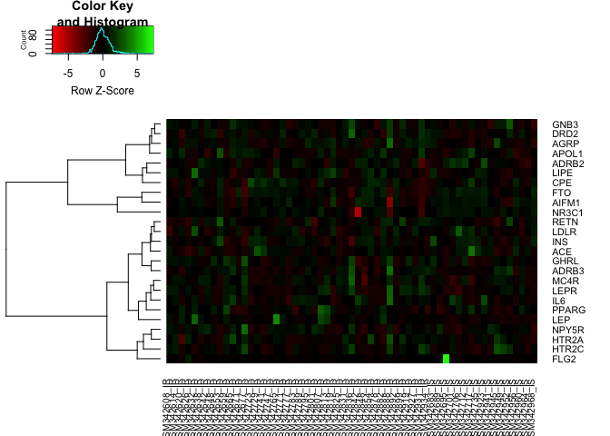

```r
heatmap.2(na.omit(as.matrix(human[ogenes, ])), col=redgreen(100), scale="row", cexRow = 0.8, trace="none", Colv = FALSE)
```

## 4.3 Practice with human data

### 4.3.1 Questions to consider

1. Do the ‘ogenes’ show any particular discriminatory pattern of expression between IR and IS subjects?
2. Are the fold changes of these changes correlated in human and mouse data (at any time point)?
3. Can you curate some known T2D associated genes and investigate if they discriminate between IR and IS groups?

# 5 Appendix

```r
getwd()
```

```
## [1] "/Users/rcha7663/Documents"
```